# Week02_TBI_SOLUTIONS

Kasia Banas

2022-11-30

You will need to load the required libraries first: tidyverse and here. We’ll also load in gt, to have prettier tables.

```r
library(tidyverse)
library(here)
library(gt) # this is a library for nice presentation of tables
```

We will be using traumatic brain injury data from a Tidy Tuesday challenge Learn more about the challenge and the data here (spend max 3 minutes looking at the linked page): https://github.com/rfordatascience/tidytuesday/blob/master/data/2020/2020-03-24/readme.md

Let’s start by loading in the data

```r
tbi_age <- read_csv('https://raw.githubusercontent.com/rfordatascience/tidytuesday/master/data/2020/2020-03-24/tbi_age.csv')
tbi_year <- read_csv('https://raw.githubusercontent.com/rfordatascience/tidytuesday/master/data/2020/2020-03-24/tbi_year.csv')
```

You need a new project set up in a dedicated directory. Now, set up folders in your working directory: raw_data, scrips, plots and tables. Put this RMarkdown document in your scripts folder.

### Task 1

Save both datasets in the raw_data folder (use the ‘here’ library)

```r
# write_csv(tbi_age, file = here("raw_data", "tbi_age.csv"))
# write_csv(tbi_year, file = here("raw_data", "tbi_year.csv"))
```

### Task 2

Use your favourite functions for eyeballing data and write a couple of sentences about each dataset (its dimensions, the variables inside, types of data, etc.)

```r
head(tbi_age)
```

```
## # A tibble: 6 × 5
##   age_group type                       injury_mechanism          numbe…¹ rate_…²
##   <chr>     <chr>                      <chr>                       <dbl>   <dbl>
## 1 0-17      Emergency Department Visit Motor Vehicle Crashes       47138    64.1
## 2 0-17      Emergency Department Visit Unintentional Falls        397190   540.
## 3 0-17      Emergency Department Visit Unintentionally struck b…  229236   312.
## 4 0-17      Emergency Department Visit Other unintentional inju…   55785    75.8
## 5 0-17      Emergency Department Visit Intentional self-harm          NA    NA
## 6 0-17      Emergency Department Visit Assault                     24360    33.1
## # … with abbreviated variable names ¹number_est, ²rate_est
```

```r
head(tbi_year)
```

```
## # A tibble: 6 × 5
##   injury_mechanism      type                        year rate_est number_est
##   <chr>                 <chr>                      <dbl>    <dbl>      <dbl>
## 1 Motor vehicle crashes Emergency Department Visit  2006     85.3     254793
## 2 Motor vehicle crashes Emergency Department Visit  2007     83.8     252459
## 3 Motor vehicle crashes Emergency Department Visit  2008     83.9     254391
## 4 Motor vehicle crashes Emergency Department Visit  2009     88.7     270240
## 5 Motor vehicle crashes Emergency Department Visit  2010     95.3     292942
## 6 Motor vehicle crashes Emergency Department Visit  2011     98.7     305694
```

### Task 3

Imagine that you are preparing a brief for the local health authority, and they have asked you to answer the following questions. For each question, write a chunk of code that would provide the answer in a clean and reproducible way.

### Task 3.1

Which injury mechanism caused the most deaths in total?

```r
tbi_age %>%
  filter(age_group == "Total" & type == "Deaths") %>%
  arrange(desc(number_est)) %>% #arrange in descending order
  head(n = 1) # show only the first row (highest number)
```

```
## # A tibble: 1 × 5
##   age_group type   injury_mechanism      number_est rate_est
##   <chr>     <chr>  <chr>                      <dbl>    <dbl>
## 1 Total     Deaths Intentional self-harm      18485      5.8
```

### Task 3.2

Looking just at the totals, what is the number of ED visits, hospitalisations and deaths associated with each injury mechanism? Present the results as a table. Save this table in your tables folder.

```r
# A good approach here is to pivot the table, so we get each injury type as a row,
# and each outcome as a column:

total_injuries_table <- tbi_age %>%
  filter(age_group == "Total") %>%
  select(-rate_est) %>%
  pivot_wider(names_from = "type", values_from = "number_est")

# And now saving the table as a .csv file:
# write_csv(total_injuries_table, file = here("tables", "total_injuries_table.csv"))

# Note: You can pipe into gt() at the end for knitting and easy presentation
```

### Task 3.3

Focusing on the oldest age group (75+), draw a bar chart illustrating the number of hospitalisations associated with each injury mechanism. Make sure that you add a title and appropriate axis labels. Save this chart in your plots folder.

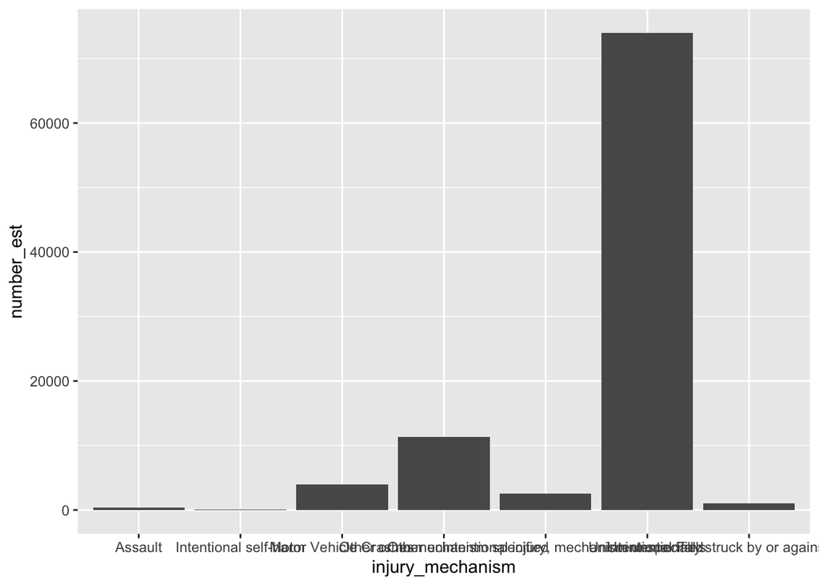

```r
# We start with a very basic, default plot
basic_plot <- tbi_age %>%
  filter(age_group == "75+" & type == "Hospitalizations") %>%
  ggplot(aes(x = injury_mechanism, y = number_est)) +
  geom_col()

basic_plot
```

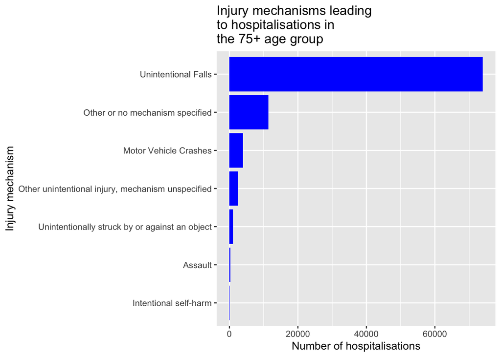

```r
# Flipping the coordinates, so that the labels don't overlap
# Also, adding a title and neat axis labels and changing the colour of the bars

flipped_plot <- tbi_age %>%
  filter(age_group == "75+" & type == "Hospitalizations") %>%
  ggplot(aes(x = reorder(injury_mechanism, number_est), y = number_est)) +
  geom_col(fill = "blue") +
  coord_flip() +
  labs(title = "Injury mechanisms leading\nto hospitalisations in\nthe 75+ age group",
       x = "Injury mechanism", y = "Number of hospitalisations")

flipped_plot
```

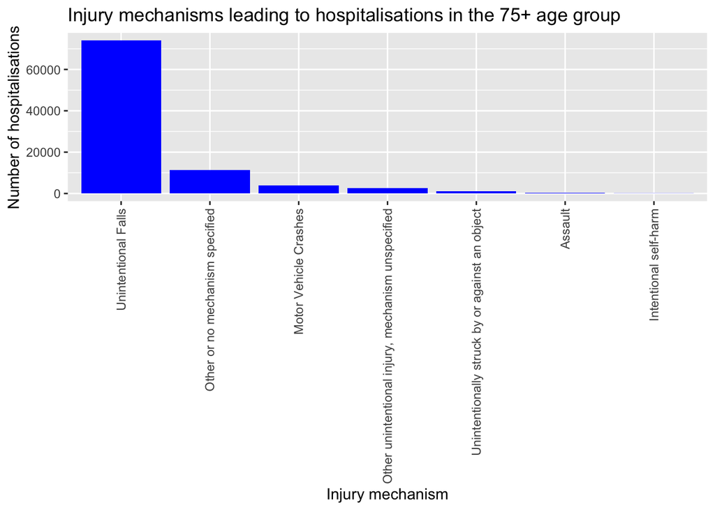

```r
# Back to a vertical plot
# Flipping the x-axis labels by 90 degrees, so they don't overlap

hosp_plot_vertical <- tbi_age %>%
  filter(age_group == "75+" & type == "Hospitalizations") %>%
  ggplot(aes(x = reorder(injury_mechanism, -number_est), y = number_est)) +
  geom_col(fill = "blue") +
  scale_x_discrete(guide = guide_axis(angle = 90)) +
  labs(title = "Injury mechanisms leading to hospitalisations in the 75+ age group", x = "Injury mechanism", y = "Number of hospitalisations")

hosp_plot_vertical
```

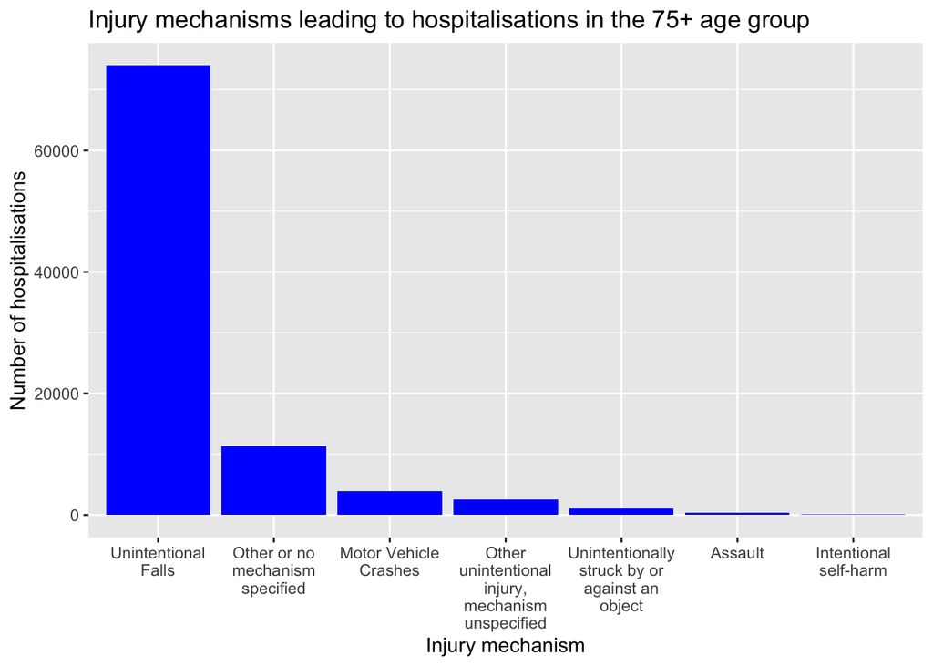

```r
# Now, changing the injury_mechanism variable in the data frame, so that
# there is a line break after every 15 characters. This will make the labels
# narrower and will help with the graph presentation. Depending on plot size,
# this may be enough to make sure that the labels don't overlap. If it's not
# enough, you can uncomment the scale_x_discrete line to rotate the labels.

tbi_age$injury_mechanism <- str_wrap(tbi_age$injury_mechanism, width = 15)

hosp_plot_string_wrap <- tbi_age %>%
  filter(age_group == "75+" & type == "Hospitalizations") %>%
  ggplot(aes(x = reorder(injury_mechanism, -number_est), y = number_est)) +
  geom_col(fill = "blue") +
  # scale_x_discrete(guide = guide_axis(angle = 90)) +
  labs(title = "Injury mechanisms leading to hospitalisations in the 75+ age group", x = "Injury mechanism", y = "Number of hospitalisations")

hosp_plot_string_wrap
```

```r
# And now saving the plot:

ggsave(here("plots", "hosp_plot.png"), plot = hosp_plot_string_wrap, dpi = 600, width = 8, height = 6, units = "in")
```

See here for ways to deal with long labels: https://stackoverflow.com/questions/1330989/rotating-and-spacing-axis-labels-in-ggplot2